# Credit Balance Prediction Analysis

## Table of Contents

- Overview
- Setup
- Result
- Project Contents
- Graphs

## Overview

This repository contains a comprehensive analysis of credit balance prediction using multiple statistical methods and machine learning approaches.

The project explores the efficacy of different modeling techniques in predicting credit card balances, addressing an important question in financial analytics.

## Setup

#### Using multiple models to evaluate Credit balance

The goal of this analysis is to test different approaches to predict numeric prediction with data frame.

I used some methods I was taught the University, especially from the book [An Introduction to Statistical Learning](https://www.statlearning.com/)

The data is Credit from the [ILSR package](https://www.rdocumentation.org/packages/ISLR/versions/1.2/topics/Credit)

This project will show which of the models are better: Those who are based on linear regression, or those who use randomness and deep learning.

#### The models

- Linear- Regression
- Lasso- Regulated linear regression
- Random Forrest- Average of multiple trees
- xgboost- Algorithm of gradient boosting trees
- Neural network- machine learning using multiple layers

#### Tools & Technologies Used

- R for data analysis and modeling
- tidyverse for data manipulation
- tidymodels for machine learning workflows
- Keras/TensorFlow for neural network implementation
- Various statistical packages (glmnet, randomForest, etc.)

## Result

### Future Work

Potential extensions of this project could include

- Ensemble modeling approaches
- More extensive hyperparameter optimization
- Application of more advanced deep learning architectures

## Project Contents

👓 Minimal code presentation- [present me](https://github.com/YoniGR94/my_credit_model_selection/blob/main/presentme.md)

👓 Recommended- see html presentation- [RMarkdown](https://github.com/YoniGR94/my_credit_model_selection/blob/main/Credit_my_deap_learnn_markdown.md)

👓 Read code- [RMarkdown script](https://github.com/YoniGR94/my_credit_model_selection/blob/main/Credit_my_deap_learnn_markdown.Rmd)

👓 Copy plots and png- [figure gfm](https://github.com/YoniGR94/my_credit_model_selection/tree/main/Credit_my_deap_learnn_markdown_files/figure-gfm)

### Graphs

Error distribution by model:

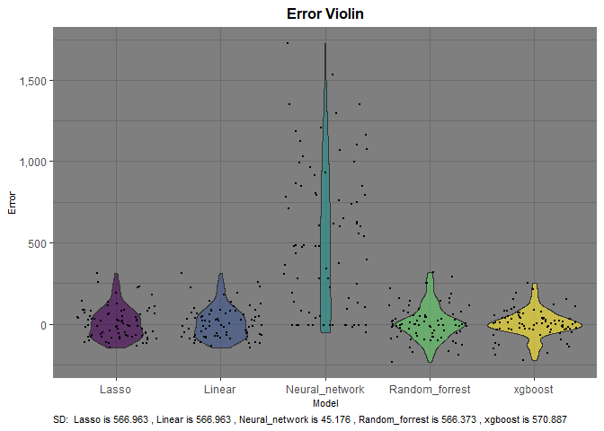

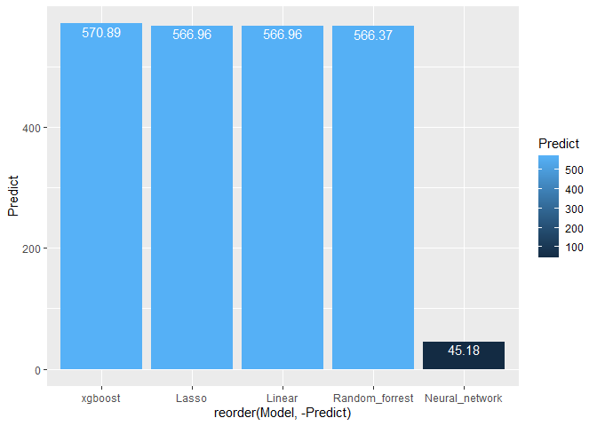

[figure not shown]